# Lecture 7. Data visualisation - Histograms (and facets)

Carlos Ramirez Alvarez

10/27/2019

In this lecture, we will learn how to make histograms and introduce a new ggplot property, facets. This property implements multipanel data plotting as we saw using trello.

We will use Moignard’s data.

```r
data <- read.csv('../data/NIHMS53736-supplement-9.csv')
str(data)
```

```
## 'data.frame':    620 obs. of  25 variables:
##  $ Cell  : Factor w/ 620 levels "CLP001","CLP002",..: 1 2 3 4 5 6 7 8 9 10 ...
##  $ Abl1  : num  18.7 19.1 17.7 18.1 19.6 ...
##  $ Eif2b1: num  16.5 19.5 19.4 18.8 17.5 ...
##  $ Erg   : num  19.6 17.9 40 18.5 17.2 ...
##  $ Eto2  : num  19.2 40 19.9 23.6 20.4 ...
##  $ Fli1  : num  15.9 17.6 15.9 16.6 15.7 ...
##  $ Gata1 : num  40 40 40 40 40 40 40 40 40 40 ...
##  $ Gata2 : num  40 40 40 40 40 40 40 40 40 40 ...
##  $ Gfi1  : num  40 19 40 19.2 40 ...
##  $ Gfi1b : num  40 18.9 40 19.5 17 ...
##  $ hHex  : num  40 18.6 18.9 17.8 18.5 ...
##  $ Kit   : num  17.9 40 16.4 18.2 17.6 ...
##  $ Ldb1  : num  16.7 18.5 20.2 18.2 20.7 ...
##  $ Lmo2  : num  18.2 40 16.7 16.8 17 ...
##  $ Lyl1  : num  15.5 15.8 16.6 17 15.8 ...
##  $ Meis1 : num  18.2 16 15.3 17.5 16.8 ...
##  $ Mitf  : num  40 40 40 40 40 ...
##  $ Mrpl19: num  18 40 40 17.8 22.7 ...
##  $ Nfe2  : num  17.5 17.8 18.6 17.9 19.5 ...
##  $ Polr2a: num  16.9 17.2 19.4 18.3 18.4 ...
##  $ PU.1  : num  18 17.8 17.2 17.5 17.4 ...
##  $ Runx1 : num  15.4 17.4 17.3 15.9 17.2 ...
##  $ SCL   : num  22.6 40 40 40 19.2 ...
##  $ Tel   : num  18 18.7 18.6 18 17.7 ...
##  $ Ubc   : num  13.6 15.1 15.3 14.7 14.2 ...
```

- Our goal is to plot gene expression distrubution for PU.1 in the different cell subtypes.

We will preprocess the data as done before. Remember that the first three letters in the Cell column refers to blood tissue subtype.

```r
library(dplyr)

transcripts <- mutate(data, subtype = substr(Cell, start = 1, stop = 3)) %>%
                  select(-Cell)
```

The `geom_histogram` can be used to create histograms. Let’s plot PU.1 expression distribution over all evaluated cells.

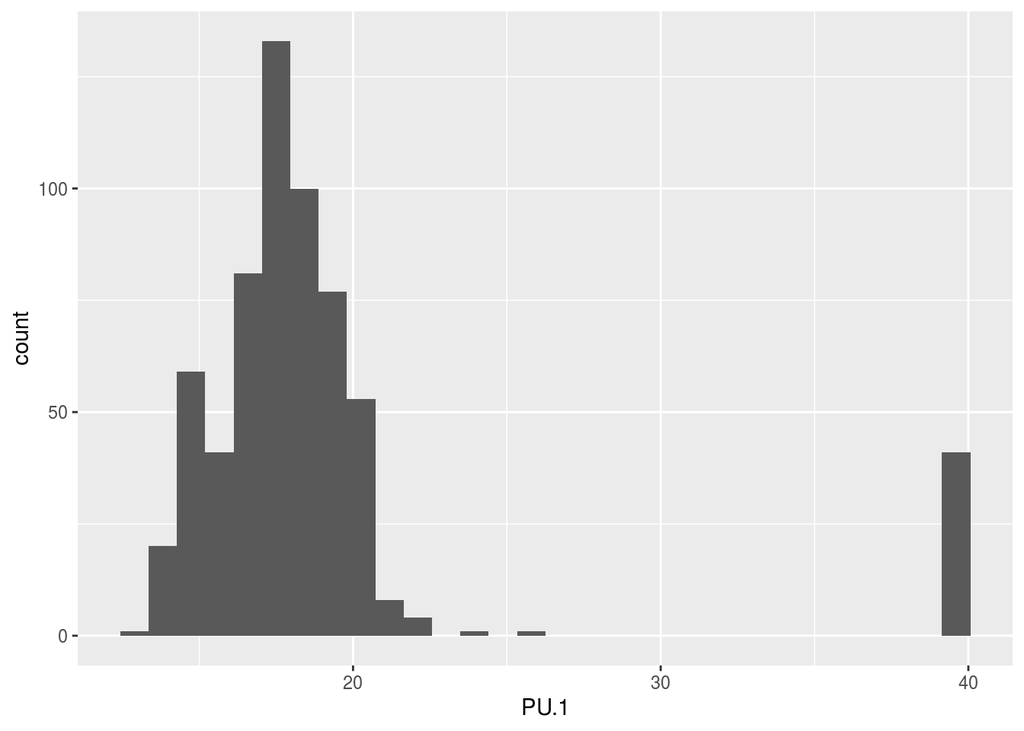

```r
library(ggplot2)

ggplot(data = transcripts, aes(x=PU.1)) +
          geom_histogram()
```

Let’s transform the data in order to get more natural visualisation in which high values in the x-axes also represents more gene expression.

We will use the following transformation:

$PU.1_t = 1 / ( log(PU.1) + 1 )$

We will use this $PU.1_t$ instead of the original value. The following piece code transforms the vaue and then creates a plot at once.

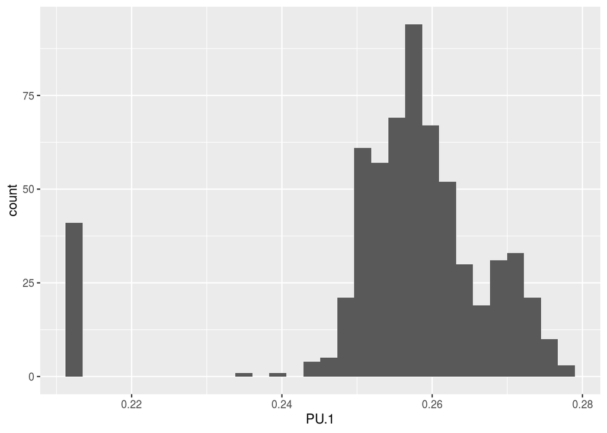

```r
library(ggplot2)

transcripts %>%
        mutate(PU.1 = 1/(log(PU.1) + 1 )) %>%       ## transforming values
          ggplot(aes(x=PU.1)) +
             geom_histogram()
```

Now, let’s visualise $PU.1_t$ gene expression by tissue subtype using colors using the parameter `fill`. This parameter fills the histogram with color and when a vector of categories or labels is given separated histograms corresponding to that groups are plotted.

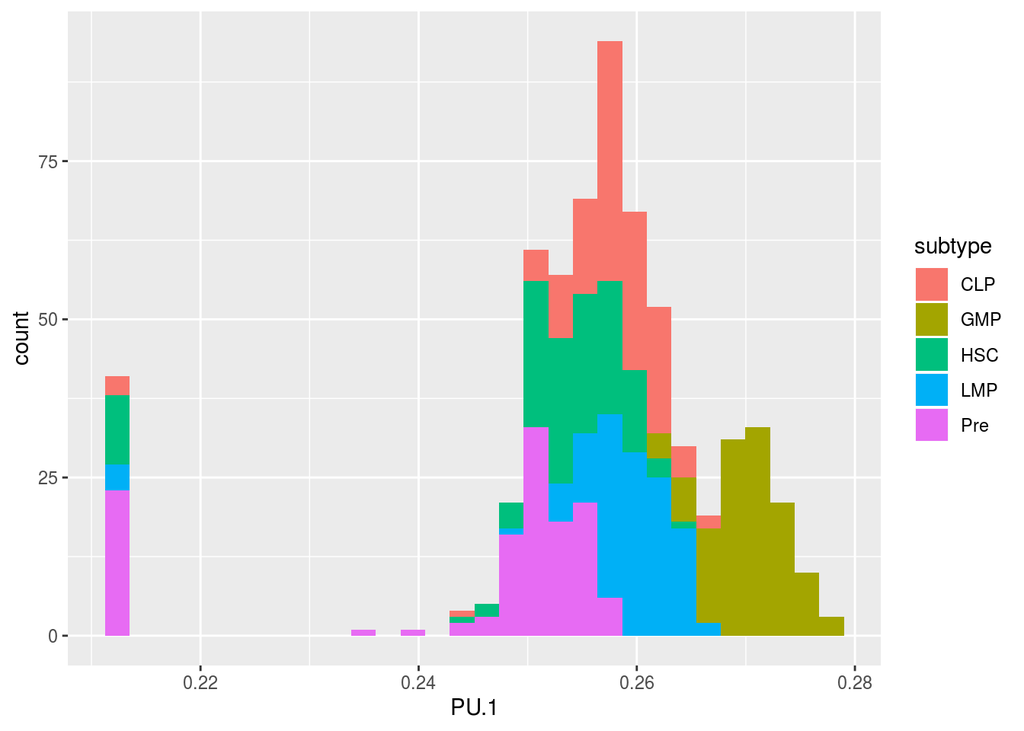

```r
library(ggplot2)

transcripts %>%
        mutate(PU.1 = 1/(log(PU.1) + 1 )) %>%
          ggplot(aes(x=PU.1, fill=subtype)) +
             geom_histogram()
```

It’s been reported that Megacariocytes/Eritrocytes Precursors (shown as Pre) have low PU.1 levels because GATA.1 is expressed in those cells which is an antagonist of PU.1 gene expression. At the other hand, Monocytes and Dendrytic cells derived from GMP do express PU.1.

Now, we will use the geometry `geom_density` that fits a smooth distribution curve through the frequency values. Additionally, we will change the theme of the plot using `theme_set` for a nice presentation.

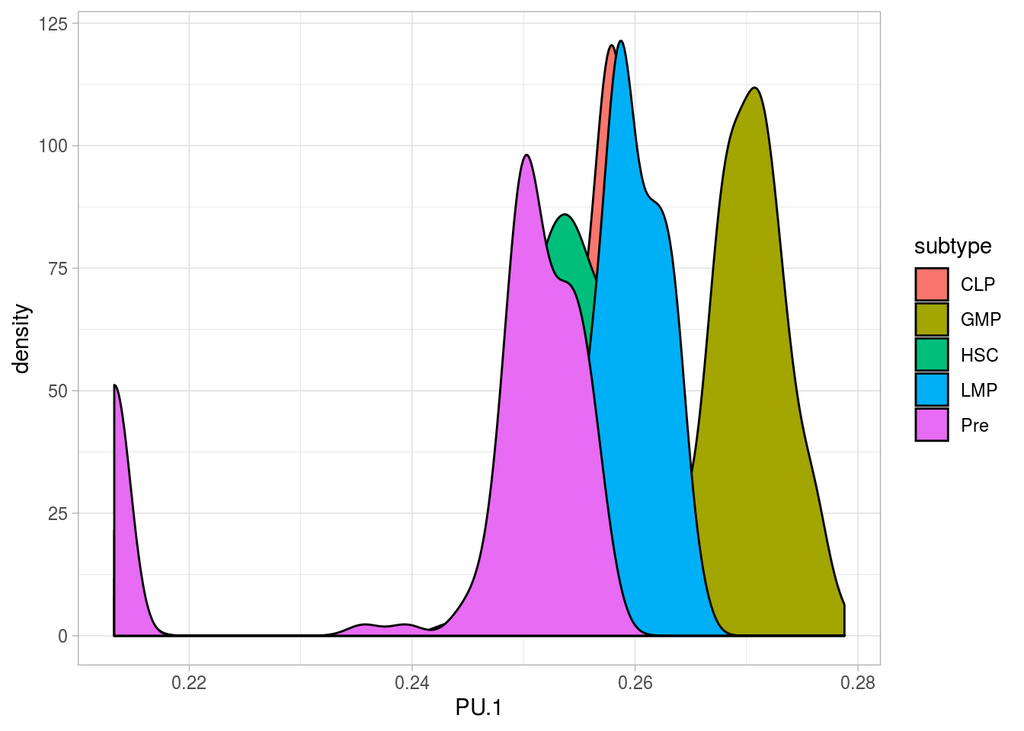

```r
library(ggplot2)

theme_set(theme_light())       ## changing theme
transcripts %>%
        mutate(PU.1 = 1/(log(PU.1) + 1 )) %>%
          ggplot(aes(x=PU.1, fill=subtype)) +
             geom_density()    ## using densities plot instead
```

This looks nice but a little bit clumpsy. We could try to separate distribution in order to improve inspection.

## Facets

We could instead of visualising all distributions in a single plot try to use multiple panels as in trello plots. We can do this in ggplot easily by using `facet_wrap`. Facets is another essential property for gpplot objects just as aesthetics, geometry and data.

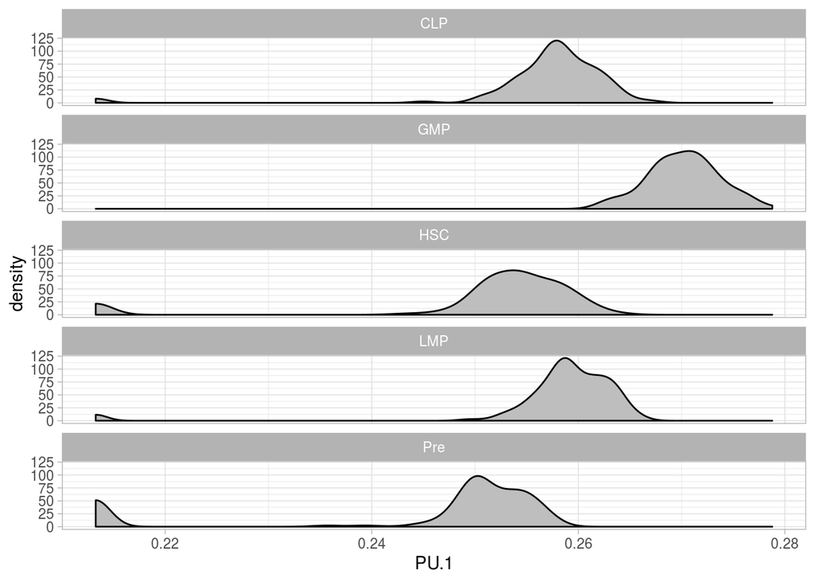

```r
library(ggplot2)

theme_set(theme_light())
transcripts %>%
        mutate(PU.1 = 1/(log(PU.1) + 1 )) %>%
          ggplot(aes(x=PU.1)) +
             geom_density(fill='gray') + ## steel blue fill
              facet_wrap(~subtype, ncol=1)   ## Using facets
```

Now, we can see more clearly that PU.1 is more expressed in GMP cells *vs* Megakariocytes/Eritrocytes precursor cells.

## Exercises

- 1. Try using `nrow=1` instead of ncol inside `facet_wrap`. What’s is the difference?
- 2. Type `theme_set()` and try another theme different from `theme_light()`. Use the tab key to list down other options.